# Наскільки точно можна спрогнозувати економність авто?

Лабораторна робота №3. Основи регресійного моделювання

Табачук Олександр Ігорович, група КН-42

## Питання та гіпотези

Наскільки точно маса, потужність, рік і регіон прогнозують `mpg` **моделі, якої немає в навчальних даних**?

**H1.** За інших рівних важчі авто мають менше mpg *(Reynolds & Kandlikar, 2007)*

**H2.** За інших рівних новіші авто мають більше mpg *(Knittel, 2011; EPA)*

Auto MPG (UCI, CC BY 4.0): 398 авто, ринок США, 1970–1982 — продовження лабораторної №2. Гіпотези підказані й EDA на тих самих даних, тому висновки **розвідувальні**.

## Зв’язок із масою сильний, але нелінійний

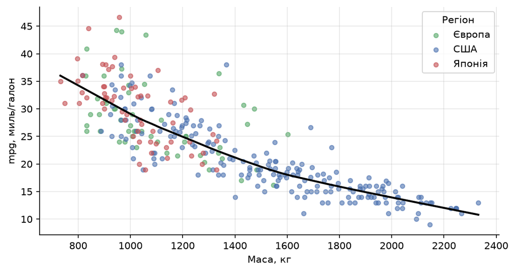

**Рішення:** перевірити квадрат маси та логарифмічну форму.

## Як перевіряли, щоб не було витоку

312 / 86поділ 80/20 за назвою моделі, seed 42

5 × 10групова CV: 50 однакових розбиттів для всіх моделей

RMSEосновна метрика, правило вибору — до тесту

- Імпутація, масштабування й поправка Дуана — лише на навчальній частині кожного розбиття
- Тест відкрито **один раз** — для обраної моделі та константи

## Базова регресія підтримує H1 і H2

| Член | Оцінка | 95 % ДІ, від | 95 % ДІ, до |
| --- | --- | --- | --- |
| Константа | 40,05 | 38,26 | 41,84 |
| Європа проти США | 2,26 | 0,87 | 3,65 |
| Японія проти США | 2,28 | 1,02 | 3,54 |
| Маса, +100 кг | −1,19 | −1,38 | −1,01 |
| Потужність, +10 к. с. | −0,12 | −0,32 | 0,07 |
| Рік, +1 | 0,73 | 0,61 | 0,84 |

+100 кг ↔︎ **−1,19 mpg**; +1 рік ↔︎ **+0,73 mpg**. Для потужності 95 % ДІ містить 0.

Ціль — mpg; кластерно-стійкі 95 % ДІ. Це умовні асоціації, а не причинні ефекти.

## Діагностика: лінійна форма не підходить

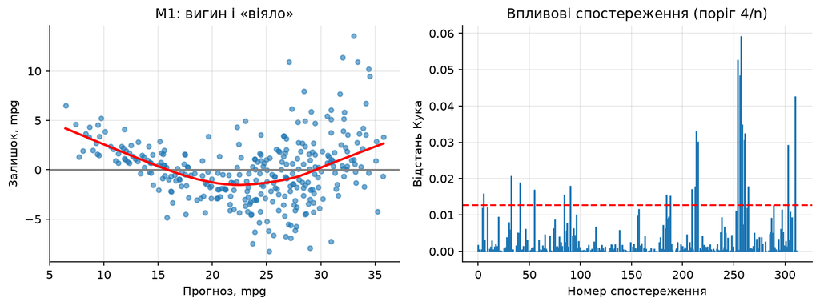

Вигин → бракує нелінійності; «віяло» → більший розкид в економних авто.

## Log-log має найменшу похибку

| Модель | RMSE | MAE | Зміна RMSE до M1 | Краща за M1, розбиттів |
| --- | --- | --- | --- | --- |
| M0 константа | 7,77 ± 0,64 | 6,52 ± 0,57 | 133,4 % | 0/50 |
| M1 лінійна | 3,33 ± 0,33 | 2,52 ± 0,22 | 0,0 % | — |
| M2a + маса² | 2,97 ± 0,28 | 2,18 ± 0,18 | −10,8 % | 49/50 |
| M2b + маса² + маса×рік | 2,88 ± 0,28 | 2,11 ± 0,18 | −13,4 % | 49/50 |
| M2c log-log | 2,79 ± 0,30 | 2,03 ± 0,20 | −16,2 % | 49/50 |
| M2d ridge, усі ознаки | 3,32 ± 0,32 | 2,54 ± 0,21 | −0,4 % | 33/50 |
| M3 випадковий ліс | 2,86 ± 0,35 | 2,03 ± 0,21 | −14,2 % | 47/50 |

Обрано **M2c (log-log)**: на 16 % точніша за лінійну. Ridge не допоміг, ліс — близько, але не краще.

CV на навчальній частині, mpg, середнє ± SD за 50 розбиттями (розбиття перекриваються).

## Обрана модель: еластичності

ln mpg ~ ln маси + ln потужності + рік + регіон

| Член | Оцінка | 95 % ДІ, від | 95 % ДІ, до |
| --- | --- | --- | --- |
| Константа | 5,304 | 5,164 | 5,444 |
| Європа проти США | 0,064 | 0,021 | 0,107 |
| Японія проти США | 0,043 | 0,006 | 0,079 |
| ln маси | −0,724 | −0,825 | −0,622 |
| ln потужності | −0,161 | −0,251 | −0,070 |
| Рік, +1 | 0,031 | 0,027 | 0,035 |

+1 % маси ↔︎ **−0,72 %** mpg; кожен новіший рік ↔︎ **+3,2 %** mpg.

## Тест: похибка на 62 % менша за константу

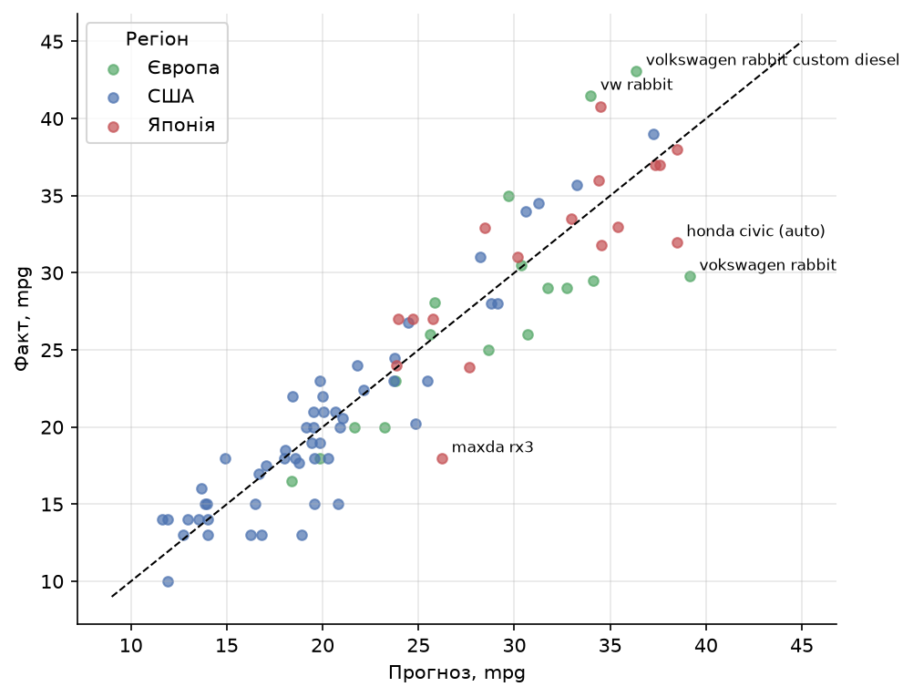

7,98RMSE константи, mpg

3,07RMSE M2c, mpg (95 % ДІ [2,38; 3,71])

| Модель | RMSE | MAE |
| --- | --- | --- |
| M0 константа | 7,98 | 6,69 |
| M2c log-log | 3,07 | 2,31 |

Найбільші промахи — економні авто: дизельний VW Rabbit, роторна Mazda RX-3. Типу пального в ознаках немає.

## Висновки та межі

≈ 3,1 mpgпохибка прогнозу для нової моделі

H1 ✓ H2 ✓узгоджуються з даними (розвідувально)

формавиграш дав правильний вигляд зв’язку, а не складніший алгоритм

- **Межі:** ринок США 1970–1982; тест не цілком незалежний від ЛР2; немає типу пального й трансмісії; асоціації, не причинність
- **Далі:** додати ці ознаки й перевірити на авто 1983–1985 рр.

Репозиторій: https://github.com/Cut1e1337/Lab03_Tabachuk_Oleksandr